[figure not shown]

# Mapping and Geospatial analysis in R

## Introduction

Geospatial analysis is one of the fastest growing areas of R. In particular, the `sf` package provides a tidy and intuitive way to analyze and visualize spatial data.

### Why map in R?

1. *Reproducibility*: Creating maps with R code means that other collaborators can easily check and replicate your work.
2. *Iteration*: With point and click software like ArcGIS, making 50 maps would be 50 times the work/time. But mapping in R, allows you to easily make many iterations of the same map with a few alterations.
3. *Easy Updates/Changes*: Writing code provides a roadmap for others (and future you!) to update the map as needed.
4. *Expansive package ecosystem*: There are several R packages that make it very convenient to get spatial data, create static and interactive maps, and perform spatial analyses. Some of these packages include:
- `sf`: For managing and analyzing spatial dataframes
- `tigris`: For downloading in Census geographies
- `ggplot2`: For making publication ready static maps
- `urbnmapr`: For automatically adding Urban styling to static maps
- `mapview`: For making exploratory interactive maps

## Some great resources

- The Urban Institute [mapping training series](https://ui-research.github.io/urbn101-mapping/)
- The Urban Institute [mapping guide](https://ui-research.github.io/r-at-urban/mapping.html) (major updates coming soon!)
- All of the vignettes for the [`sf` package](https://cran.r-project.org/web/packages/sf/sf.pdf)
- Robin Lovelace, [Geocomputation with R](https://geocompr.robinlovelace.net/index.html)

## Reading in spatial data

```r
library(tidyverse)
library(sf)
library(urbnthemes)
library(urbnmapr)
library(tigris)
library(mapview)
```

### Reading in shapefiles/geojsons

The `st_read()` function allows you to read in any spatial file format, such as shapefiles (`.shp`) or GeoJSONs (`.geojson`), as an `sf` dataframe. Once read in, you can reproject the coordinate reference system for your data. When mapping and performing geospatial operations, it is important that all data are in the same projection.

```r
list.files("shapefiles")
```

```
## [1] "2015 MSA Boundary.cpg"     "2015 MSA Boundary.dbf"
## [3] "2015 MSA Boundary.prj"     "2015 MSA Boundary.sbn"
## [5] "2015 MSA Boundary.sbx"     "2015 MSA Boundary.shp"
## [7] "2015 MSA Boundary.shp.xml" "2015 MSA Boundary.shx"
```

```r
msa_boundary <- st_read(dsn = "shapefiles/2015 MSA Boundary.shp")
msa_boundary <- st_transform(msa_boundary, crs = 4326)
```

### Reading in CSV’s

If you have a CSV or other dataset that contains latitudes and longitudes, you can easily convert your data to a `sf` point dataframe. It is important to know what coordinate reference system the coordinates are based on, so you can properly assign the CRS or projection. Note that `st_set_crs` is used to assign a projection; `st_transform` is used to alter a projection that already exists.

```r
banks <- read_csv("data/fdic-sod-dc_2017.csv")

banks_sf <- banks %>%
  # Filter out 2 rows without lat or lons
  filter(!is.na(sims_longitude) | !is.na(sims_latitude)) %>%
  # Convert regular dataframe to an sf dataframe. Need to specify lon, lat (in that order!)
  st_as_sf(coords = c("sims_longitude", "sims_latitude")) %>%
  st_set_crs(4326)
```

### Reading in Census boundaries

There are many packages that make it easy to read in Census boundaries. The `tigris` package for example allows you to pull states, tracts, CBSAs, and even roads and military bases. For a full list of supported Census geographies see [here](https://github.com/walkerke/tigris).

```r
options(tigris_class = "sf", use_tigris_cache = FALSE)

dc_tracts <- tracts(state = "DC",
                    cb = TRUE,
                    year = 2010) %>%
  st_transform(crs = 4326)
```

The `urbnmapr` package contains geographic data that can be used to easily make state and county level maps, with AL and HI displayed as insets. This package also supports US territories.

```r
dc <- get_urbn_map(map = "states", sf = TRUE) %>%
  filter(state_fips == "11") %>%
  st_transform(crs = 4326)
```

## Static Mapping

`geom_sf` from `ggplot2` allows you to map point, line, polygon, and multipolygon `sf` dataframes. The syntax follows that of other `geom_*` functions- provide a data set and a set of aesthetics. If you are using an `sf` dataframe (which contains the coordinates saved in a column called `geometry`), then you are not required to provide any aesthetics. But you can if you say want to color in states by a particular variable.

You can also layer geoms on top of each other; they will appear from bottom to top.

[figure not shown]

```r
ggplot() +
  geom_sf(data = msa_boundary,
          mapping = aes()) +
  geom_sf(data = banks_sf,
          mapping = aes(),
          alpha = .2,
          color = palette_urbn_cyan[5],
          stroke = FALSE) +
  theme_urbn_map() +
  labs(title = "FDIC Insured Bank Branches in the Washington DC MSA")
```

For examples of choropleth maps, see the [`urbnmapr` vignette.](https://github.com/UrbanInstitute/urbnmapr). For examples of other types of maps, see the Urban Institute [mapping guide](https://ui-research.github.io/r-at-urban/mapping.html).

## Clipping

`st_crop` will crop your data to the bounding box of another spatial data set.

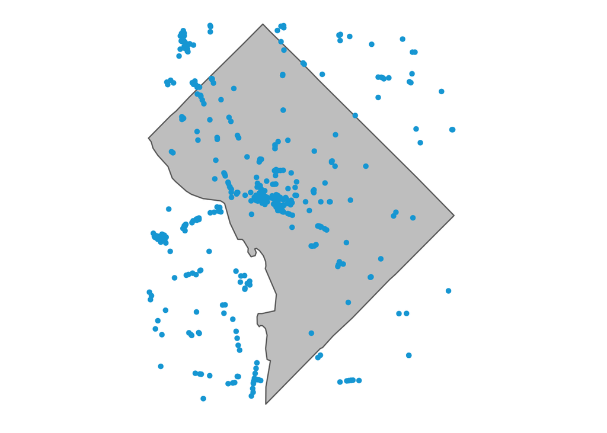

```r
banks_crop <- st_crop(banks_sf, dc)

ggplot() +
  geom_sf(data = dc,
          mapping = aes(),
          fill = "grey") +
  geom_sf(data = banks_crop,
          mapping = aes(),
          color = palette_urbn_cyan[5]) +
  theme_urbn_map()
```

`st_intersection` will provide an exact clip.

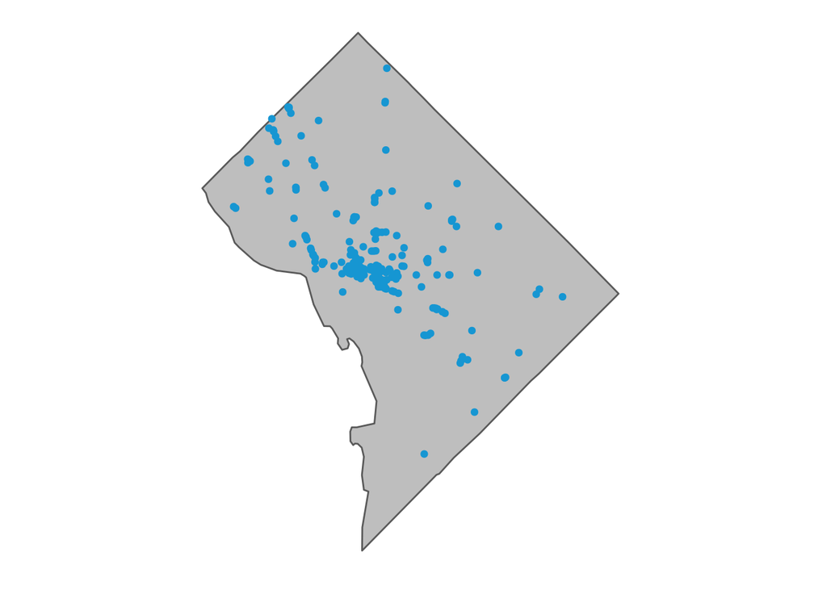

```r
banks_int <- st_intersection(banks_sf, dc)

ggplot() +
  geom_sf(data = dc,
          mapping = aes(),
          fill = "grey") +
  geom_sf(data = banks_int,
          mapping = aes(),
          color = palette_urbn_cyan[5]) +
  theme_urbn_map()
```

## Spatial joins

Say, for instance, you want to map out census tracts in DC, colored by the number of FDIC-insured bank branches they have. Doing this would involve:

1. Performing a point to polygon spatial join to figure out the Census tract that each bank falls into
2. Counting the number of banks by Census tracts
3. Making a map

The function `st_join` has many different options to spatially join geometries. The [`sf` cheatsheet](https://github.com/rstudio/cheatsheets/raw/master/sf.pdf) is a great resource for remembering and determining which function to use. When using `st_join`, the the geometry of the first object is retained, and the geometry of the second object is lost.

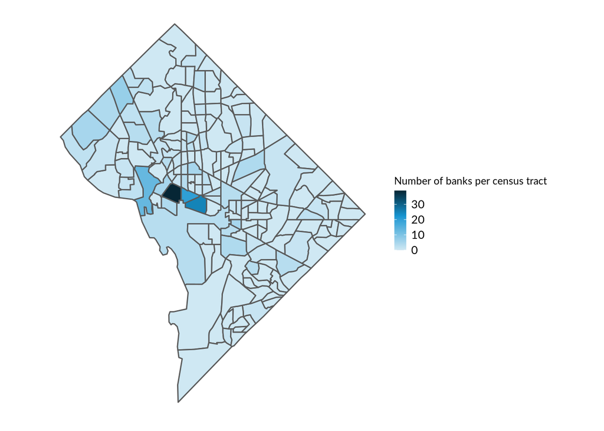

```r
# Perform spatial join between banks (point) and tracts (polygons)
banks_with_tract_appended <- st_join(banks_int, dc_tracts, join = st_intersects)

# Count number of banks by tract
bank_count_by_tract = banks_with_tract_appended %>%
  # GEO_ID = unique id for a tract
  count(GEO_ID,
        name = "num_banks") %>%
  st_drop_geometry()

# Append count of number of banks to dc_tracts dataframe
dc_tracts = dc_tracts %>%
  left_join(bank_count_by_tract,
            by = "GEO_ID") %>%
  mutate(num_banks = ifelse(is.na(num_banks), 0, num_banks))

# Create map of banks by Census tract
 dc_tracts %>%
  ggplot() +
  geom_sf(mapping = aes(fill = num_banks)) +
  scale_fill_gradientn() +
  theme_urbn_map() +
  labs(fill = "Number of banks per census tract")
```

## Buffers

The function `st_buffer` can be used to create buffers around geometries. It is important to reproject your data out of long/lat based projectsion to calculate accurate buffers.

Here, I project the bank coordinates into Marlyand State plane in feet in order to calculate a half mile buffer. `library(units)` is helpful for setting and converting between units.

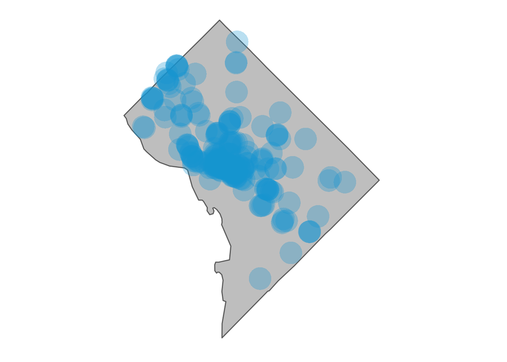

```r
banks_proj <- banks_int %>%
  st_transform(crs = 2248)

banks_buffer <- banks_proj %>%
  st_buffer(units::set_units(.5, mi) %>% units::set_units(ft)) %>%
  st_transform(crs = 4326)

ggplot() +
  geom_sf(dc, mapping = aes(),
          fill = "grey") +
  geom_sf(banks_buffer, mapping = aes(),
          fill = "#1696d2", alpha = .3, color = NA) +
  theme_urbn_map()
```

## Interactive Mapping

The `mapview` package makes it very easy to create interactive maps with `sf` dataframes. All you have to do is run `mapview(your_sf_object)`. You can layer multiple `sf` dataframes on top of each other with `mapview(sf1) + mapview(sf2)`

```r
mapview(dc_tracts)
```

[interactive chart not shown]

```r
mapview(dc_tracts) + mapview(banks_int, col.regions = palette_urbn_green[6])
```

[interactive chart not shown]

For more information on the options available on the `mapview` libary, see Day 4 of our [Mapping 101 training](https://ui-research.github.io/urbn101-mapping/).